# 7-7 mMRC Breathlessness scale

Analyse of the modified Medical Research Council breathlessness scale.

Authors

Affiliations

James Totterdell

University of Sydney

Rob Mahar

University of Melbourne

Published

July 14, 2022

## Preamble

**Load packages**

```r
library(tidyverse)
library(labelled)
library(kableExtra)
library(cmdstanr)
library(posterior)
library(bayestestR)
library(bayesplot)
library(matrixStats)
library(ggdist)
library(patchwork)
library(lubridate)

theme_set(theme_classic(base_size = 10, base_family = "Palatino") +
  theme(panel.grid = element_blank(),
        strip.background = element_blank()))
bayesplot_theme_set(theme_set(theme_classic(base_size = 10, base_family = "Palatino") +
  theme(panel.grid = element_blank(),
        strip.background = element_blank())))
```

**Prepare dataset**

```r
devtools::load_all()
all_dat <- read_all_no_daily()

breath_labels <-c("Only breathless with strenuous exercise",
                  "Short of breath when hurrying on level ground or walking up a slight hill",
                  "Walks slower than most people of the same age because of breathlessness on level",
                  "Stops for breath after walking about 100 metres or after a few minutes on level ground",
                  "Too breathless to leave the house, or breathless when dressing or undressing")

breath_labels_short <-c("Only breathless with strenuous exercise",
                     "Short of breath up a slight hill",
                     "Walks slower than most people of the same age",
                     "Stops for breath after walking about 100 metres",
                     "Too breathless to leave the house")

acs_itt_dat <- all_dat %>%
  filter_acs_itt() %>%
  transmute_model_cols_grp_aus_nz() %>%
  mutate(
    out_mmrc_lab = fct_explicit_na(
      factor(out_mmrc_scale,
             levels = c(1:5, 0),
             labels = c(breath_labels_short, "Not asked"))))
acs_itt_nona_dat <- all_dat %>%
  filter_acs_itt()  %>%
  filter(!is.na(out_mmrc_scale), out_mmrc_scale != 0) %>%
  transmute_model_cols_grp_aus_nz() %>%
  mutate(out_mmrc_lab = fct_explicit_na(
  factor(out_mmrc_scale,
         levels = c(1:5, 0),
         labels = c(breath_labels_short, "Not asked"))))
acs_itt_nona2_dat <- all_dat %>%
  filter_acs_itt()  %>%
  filter(!is.na(out_mmrc_scale)) %>%
  transmute_model_cols_grp_aus_nz() %>%
  mutate(out_mmrc_lab = fct_explicit_na(
  factor(out_mmrc_scale,
         levels = c(1:5, 0),
         labels = c(breath_labels_short, "Not asked")))) %>%
  mutate(out_mmrc_scale = out_mmrc_scale + 1)

# Concurrent enrolments for C2
acs_itt_concurc2_dat <- acs_itt_dat %>%
  filter_concurrent_intermediate()
acs_itt_concurc2_nona_dat <- acs_itt_concurc2_dat %>%
  filter(!is.na(out_mmrc_scale), out_mmrc_scale != 0)

# Concurrent enrolments for C3
acs_itt_concurc3_dat <- acs_itt_dat %>%
  filter_concurrent_std_aspirin()
acs_itt_concurc3_nona_dat <- acs_itt_concurc3_dat %>%
  filter(!is.na(out_mmrc_scale), out_mmrc_scale != 0)

# Concurrent enrolments for C4
acs_itt_concurc4_dat <- acs_itt_dat %>%
  filter_concurrent_therapeutic()
acs_itt_concurc4_nona_dat <- acs_itt_concurc4_dat %>%
  filter(!is.na(out_mmrc_scale), out_mmrc_scale != 0)
```

**Compiles stan models.**

```r
seed <- 59579
model_tx           <- cmdstan_model(file.path("stan", "ordinal", "logistic_cumulative.stan"))
model_site         <- cmdstan_model(file.path("stan", "ordinal", "logistic_cumulative_site.stan"))
model_region_epoch <- cmdstan_model(file.path("stan", "ordinal", "logistic_cumulative_epoch.stan"))
model_site_epoch   <- cmdstan_model(file.path("stan", "ordinal", "logistic_cumulative_epoch_site.stan"))
```

**Helper functions**

```r
# Makes stan data for ordinal outcome.
make_stan_data <- function(dat, vars, outcome, beta_sd_var, ctr = contr.orthonorm, p_mult = 2) {

  X <- make_X_design(dat, vars, ctr)
  attX <- attr(X, "contrasts")
  X <- X[, -1]
  attr(X, "contrasts") <- attX
  nXtrt <- sum(grepl("rand", colnames(X)))
  beta_sd <- c(rep(1, nXtrt), beta_sd_var)

  y <- as.integer(dat[[outcome]])
  N <- dim(X)[1]
  K <- dim(X)[2]
  J <- max(y)

  epoch <- dat[["epoch"]]
  M_epoch <- max(dat[["epoch"]])
  region <- as.integer(dat[["ctry"]])
  M_region <- max(region)
  site <- dat[["site_num"]]
  M_site <- length(levels(dat[["site"]]))
  region_by_site <- dat %>%
    dplyr::count(ctry_num, site_num) %>%
    pull(ctry_num)

  list(
    N = N, K = K, X = X, y = y, J = J, p_par = rep(p_mult, J),
    M_region = M_region, region = region,
    M_site = M_site, site = site,
    M_epoch = M_epoch, epoch = epoch,
    region_by_site = region_by_site,
    beta_sd = beta_sd)
}

# Wrapper to run stan
run_stan <- function(model, data, ...) {
  model[["sample"]](data = data,
                    seed = seed,
                    refresh = 0,
                    iter_sampling = 2500,
                    chains = 8,
                    parallel_chains = min(8, parallel::detectCores()),
                    ...
  )
}
```

The mMRC Breathlessness Scale was only asked of participants who reported that they had been “experiencing shortness of breath that is worse than or new since before they got COVID” (`D28_BreathSinceGettingCovid == Yes`). Therefore, the outcome as analysed is conditional on a patient having worse breathlessness than before.

Given that a patient who is not experiencing *worse* shortness of breath, may have still been experiencing *some* shortness of breath before they got COVID, it does not make sense to assign these participants to a score of 0 on the scale.

This means that most of the data is missing, as only about ~ 20% of participants responded “Yes” to experiencing worse shortness of breath. One option is to augment the scale and threat it as a measure of “worsening” of shortness of breath, where a “No” to `D28_BreathSinceGettingCovid` is taken as a score of -1, and for a “Yes”, the score is taken as that reported for `D28_BreathScale`.

## Descriptive

**Summarise the ordinal component**

```r
descriptive_table <- acs_itt_dat %>%
  dplyr::count(CAssignment, out_mmrc_lab) %>%
  spread(CAssignment, n, fill = 0) %>%
  mutate(
    Overall = C1 + C2 + C3 + C4,
    across(C1:Overall, ~ sprintf("%i (%.0f)", .x, 100 * .x / sum(.x)))
  ) %>%
  rename(
    Low = C1,
    Intermediate = C2,
    `Low\nwith aspirin` = C3,
    Therapeutic = C4
  )

tab <- kable(
  descriptive_table,
  format = "latex",
  booktabs = TRUE,
  escape = F,
  col.names = linebreak(c("mMRC breathlessness scale (day 28)", names(descriptive_table)[-1]), align = "c"),
  caption = "Secondary endpoint breakdown - mMRC breathlessness scale (day 28).",
  align = "lrrrrr") %>%
  kable_styling(font_size = 9, latex_options = "HOLD_position")
save_tex_table(tab, "outcomes/secondary/7-7_mmrc_scale_descriptive")

kable(
  descriptive_table,
  col.names = c("mMRC breathlessness scale (day 28)", names(descriptive_table)[-1]),
  caption = "Secondary endpoint breakdown - mMRC breathlessness scale (day 28).",
  align = "lrrrrr") %>%
  kable_styling(font_size = 11) %>%
  collapse_rows(1, valign = "top", latex_hline = 'custom', custom_latex_hline = 1)
```

| mMRC breathlessness scale (day 28) | Low | Intermediate | Low with aspirin | Therapeutic | Overall |
| --- | --- | --- | --- | --- | --- |
| Only breathless with strenuous exercise | 40 (7) | 50 (8) | 26 (9) | 2 (4) | 118 (8) |
| Short of breath up a slight hill | 47 (8) | 39 (6) | 16 (6) | 4 (8) | 106 (7) |
| Walks slower than most people of the same age | 12 (2) | 11 (2) | 15 (5) | 3 (6) | 41 (3) |
| Stops for breath after walking about 100 metres | 14 (2) | 8 (1) | 1 (0) | 2 (4) | 25 (2) |
| Too breathless to leave the house | 2 (0) | 2 (0) | 1 (0) | 0 (0) | 5 (0) |
| Not asked | 462 (76) | 474 (77) | 212 (75) | 33 (66) | 1181 (76) |
| (Missing) | 33 (5) | 29 (5) | 12 (4) | 6 (12) | 80 (5) |

Secondary endpoint breakdown - mMRC breathlessness scale (day 28).

**Graph the sample cumulative logits**

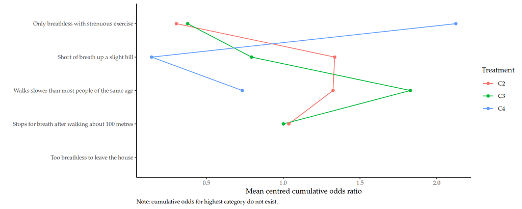

```r
acs_itt_nona_dat %>%
  group_by(CAssignment, out_mmrc_lab) %>%
  summarise(n = n()) %>%
  mutate(p = n/sum(n)) %>%
  select(-n) %>%
  spread(CAssignment, p, fill = 0) %>%
  mutate(across(C1:C4, ~ logit(cumsum(.x )))) %>%
  mutate(across(C2:C4, ~ .x/C1),
         across(C2:C4, ~ ifelse(.x == Inf, NA, .x))) %>%
  select(-C1) %>%
  mutate(across(C2:C4, ~ .x/(mean(.x, na.rm = TRUE)))) %>%
  gather("id", "value", 2:4) %>%
  rename(Treatment = id, `Cumulative odds ratio` = value) %>%
  ggplot(., aes(reorder(out_mmrc_lab, desc(out_mmrc_lab)), `Cumulative odds ratio`, group = Treatment, col=Treatment)) +
  geom_line() + geom_point() +
  coord_flip() +
  xlab("") + ylab("Mean centred cumulative odds ratio") +
  labs(caption = "Note: cumulative odds for highest category do not exist.") +
  theme(plot.caption = element_text(hjust = 0))
```

## Analyses

### Primary Model

```r
fit_primary_model <- function(dat, ctr = contr.orthonorm) {

  mdat <- make_stan_data(
    dat = dat,
    vars = c("inelgc3", "agegte60", "ctry"),
    outcome = "out_mmrc_scale",
    beta_sd_var = c(10, 2.5, 1, 1),
    ctr = ctr)
  mfit <- run_stan(model_site_epoch, mdat, adapt_delta = 0.99)
  mdrws <- as_draws_rvars(
    mfit$draws(c("alpha", "beta", "gamma_site", "gamma_epoch",
                 "tau_site", "tau_epoch", "y_ppc")))

  # Add names
  epoch_map <- dat %>% dplyr::count(epoch, epoch_lab)
  site_map <- dat %>% dplyr::count(site_num, site)
  names(mdrws$beta) <- colnames(mdat$X)
  names(mdrws$gamma_epoch) <- epoch_map$epoch_lab
  names(mdrws$gamma_site) <- site_map$site
  # Convert to treatment log odds ratios
  mdrws$Acon <- attr(mdat$X, "contrasts")$randA %**%
    mdrws$beta[grepl("randA[0-9]", names(mdrws$beta))]
  mdrws$Ccon <- attr(mdat$X, "contrasts")$randC %**%
    mdrws$beta[grepl("randC[0-9]", names(mdrws$beta))]
  mdrws$trtA <- mdrws$Acon[-1] - mdrws$Acon[1]
  mdrws$trtC <- mdrws$Ccon[-1] - mdrws$Ccon[1]
    mdrws$compare <- c(
    "Intermediate vs low" = exp(mdrws$trtC[1]),
    "Low with aspirin vs low" = exp(mdrws$trtC[2]),
    "Therapeutic vs low" = exp(mdrws$trtC[3]),
    "Intermediate vs low with aspirin" = exp(mdrws$trtC[1] - mdrws$trtC[2]),
    "Intermediate vs therapeutic" = exp(mdrws$trtC[1] - mdrws$trtC[3]),
    "Low with aspirin vs therapeutic" = exp(mdrws$trtC[2] - mdrws$trtC[3])
  )
  mdrws$OR <- c(
    setNames(exp(mdrws$trtC), c("Intermediate", "Low with aspirin", "Therapeutic")),
    "Ineligible aspirin" = exp(mdrws$beta[which(grepl("inelg", colnames(mdat$X)))]),
    "Age \u2265 60" = exp(mdrws$beta[which(grepl("age", colnames(mdat$X)))]),
    setNames(exp(mdrws$beta[which(grepl("ctry", colnames(mdat$X)))]), c("Australia/New Zealand", "Nepal"))
  )
  return(list(dat = mdat, fit = mfit, drws = mdrws))
}
res <- fit_primary_model(acs_itt_nona_dat)
```

```
Running MCMC with 8 chains, at most 4 in parallel...

Chain 3 finished in 35.2 seconds.
Chain 4 finished in 42.2 seconds.
Chain 2 finished in 43.7 seconds.
Chain 1 finished in 67.0 seconds.
Chain 5 finished in 46.9 seconds.
Chain 6 finished in 48.9 seconds.
Chain 7 finished in 51.1 seconds.
Chain 8 finished in 39.6 seconds.

All 8 chains finished successfully.
Mean chain execution time: 46.8 seconds.
Total execution time: 106.8 seconds.
```

**Odds ratio summary table**

```r
save_tex_table(
  odds_ratio_summary_table(res$drws$OR, "latex"),
  "outcomes/secondary/7-7-primary-model-acs-itt-summary-table")
odds_ratio_summary_table(res$drws$OR)
```

| Parameter | Median | 95% CrI | Mean (SD) | Pr(OR < 1) |
| --- | --- | --- | --- | --- |
| Intermediate | 0.71 | (0.42, 1.19) | 0.73 (0.20) | 0.91 |
| Low with aspirin | 1.09 | (0.57, 2.11) | 1.16 (0.40) | 0.40 |
| Therapeutic | 0.73 | (0.24, 2.25) | 0.86 (0.54) | 0.71 |
| Ineligible aspirin | 1.02 | (0.24, 4.02) | 1.30 (1.06) | 0.49 |
| Age ≥ 60 | 1.47 | (0.92, 2.39) | 1.52 (0.38) | 0.05 |
| Australia/New Zealand | 2.65 | (0.72, 9.65) | 3.30 (2.44) | 0.07 |
| Nepal | 1.36 | (0.31, 5.39) | 1.73 (1.39) | 0.33 |

Posterior summaries for model parameters (fixed-effects).

**Odds ratio summary for epoch and site**

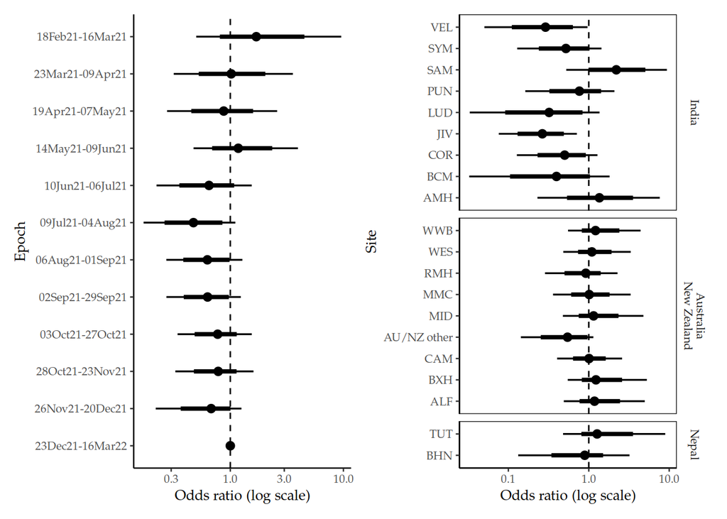

Summary of epoch and site posterior odds ratios.

```r
p <- plot_epoch_site_terms(
  exp(res$drws$gamma_epoch),
  exp(res$drws$gamma_site),
  factor(res$dat$region_by_site,
         labels = c("India", "Australia\nNew Zealand", "Nepal"))
)
pth <- file.path("outputs", "figures", "outcomes", "secondary", "7-7-primary-model-epoch-site-terms.pdf")
ggsave(pth, p, width = 6, height = 4.5)
p
```

**Posterior contrasts**

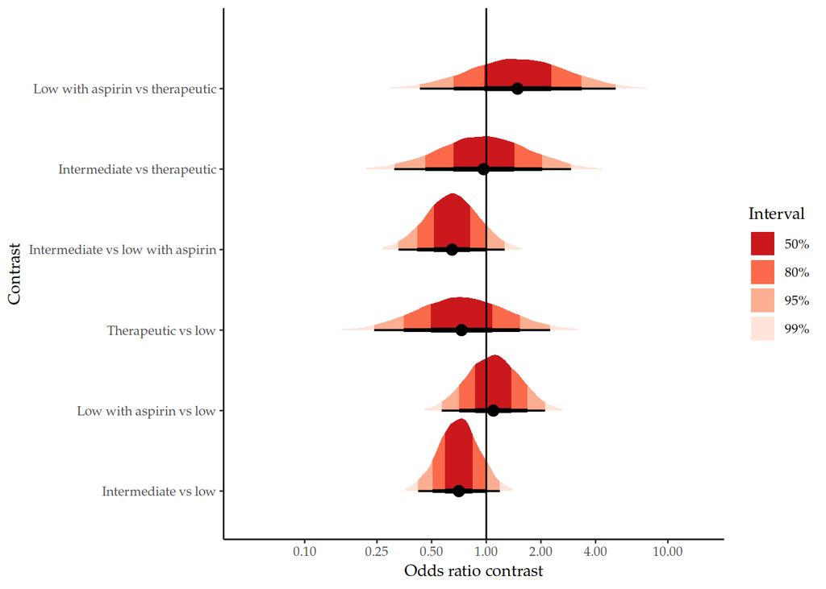

Summaries on comparisons.

```r
plot_or_densities(res$drws$compare)
```

**Diagnostics**

```r
res$fit$summary(
  c("alpha", "beta", "gamma_epoch", "gamma_site", "tau_epoch", "tau_site")) %>%
  print(n = Inf)
```

```
# A tibble: 49 × 10
   variable    mean   median    sd   mad      q5     q95  rhat ess_bulk ess_tail
   <chr>      <dbl>    <dbl> <dbl> <dbl>   <dbl>   <dbl> <dbl>    <dbl>    <dbl>
 1 alpha[1] -1.22   -1.20    0.545 0.546 -2.15   -0.364   1.00    5886.   10130.
 2 alpha[2]  0.684   0.702   0.518 0.516 -0.192   1.51    1.00    6215.    9621.
 3 alpha[3]  1.89    1.90    0.524 0.524  1.00    2.72    1.00    6534.    9351.
 4 alpha[4]  3.78    3.78    0.630 0.626  2.75    4.82    1.00    8907.   10770.
 5 beta[1]  -0.277  -0.274   0.450 0.449 -1.01    0.463   1.00   20000.   16228.
 6 beta[2]   0.165   0.168   0.240 0.238 -0.233   0.559   1.00   19871.   16514.
 7 beta[3]  -0.201  -0.200   0.283 0.279 -0.671   0.262   1.00   19261.   16214.
 8 beta[4]  -0.0243 -0.0217  0.591 0.593 -0.997   0.940   1.00   17148.   15573.
 9 beta[5]  -0.230  -0.232   0.352 0.346 -0.803   0.352   1.00   30619.   14840.
10 beta[6]   0.0115  0.0186  0.715 0.712 -1.18    1.18    1.00   27768.   14554.
11 beta[7]   0.389   0.387   0.245 0.247 -0.0106  0.790   1.00   25196.   15800.
12 beta[8]   0.974   0.976   0.662 0.659 -0.112   2.06    1.00   10977.   13902.
```

[output cut: 37 more lines]

```r
res$fit$diagnostic_summary()
```

```
$num_divergent
[1] 0 0 0 0 0 0 0 0

$num_max_treedepth
[1] 0 0 0 0 0 0 0 0

$ebfmi
[1] 0.7070099 0.6354631 0.6956543 0.6526245 0.6458634 0.7212142 0.6525408
[8] 0.6727358
```

**Trace plots**

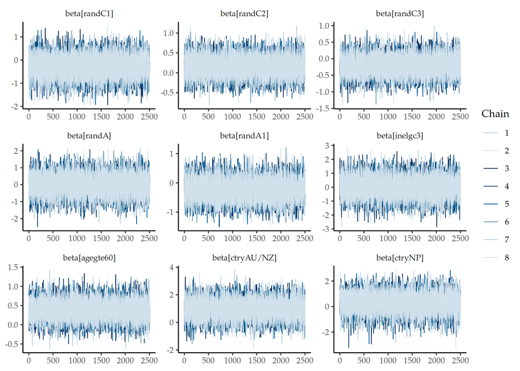

```r
mcmc_trace(res$drws["beta"])
```

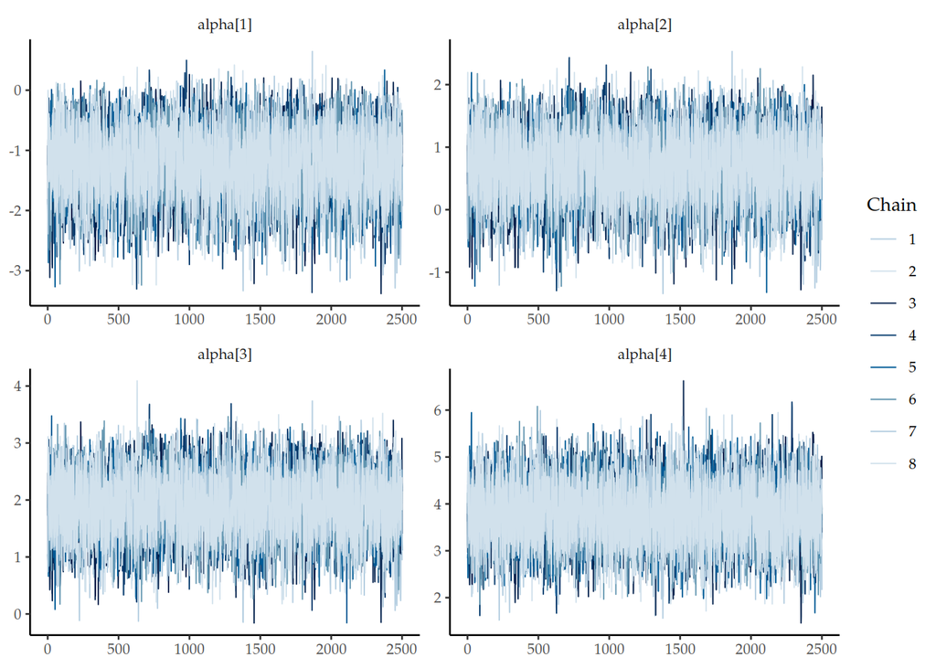

```r
mcmc_trace(res$drws["alpha"])
```

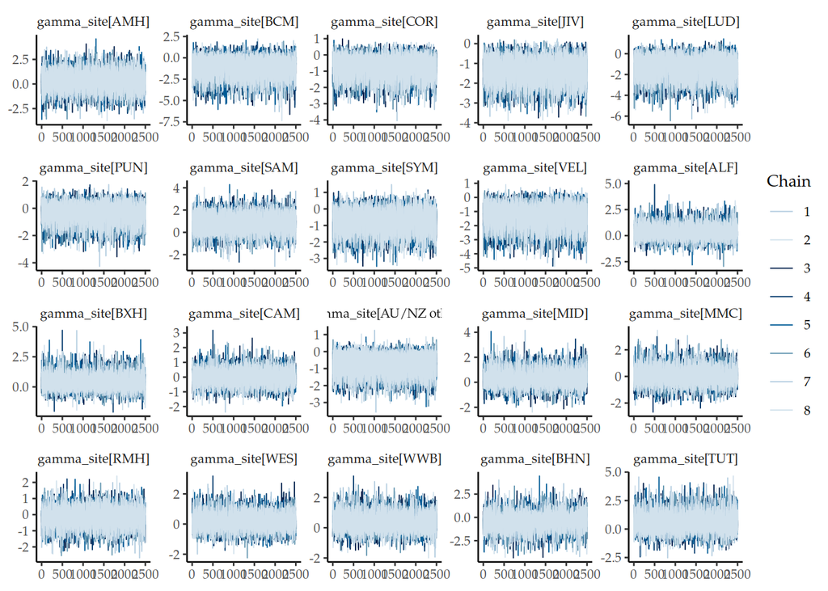

```r
mcmc_trace(res$drws["gamma_site"])
```

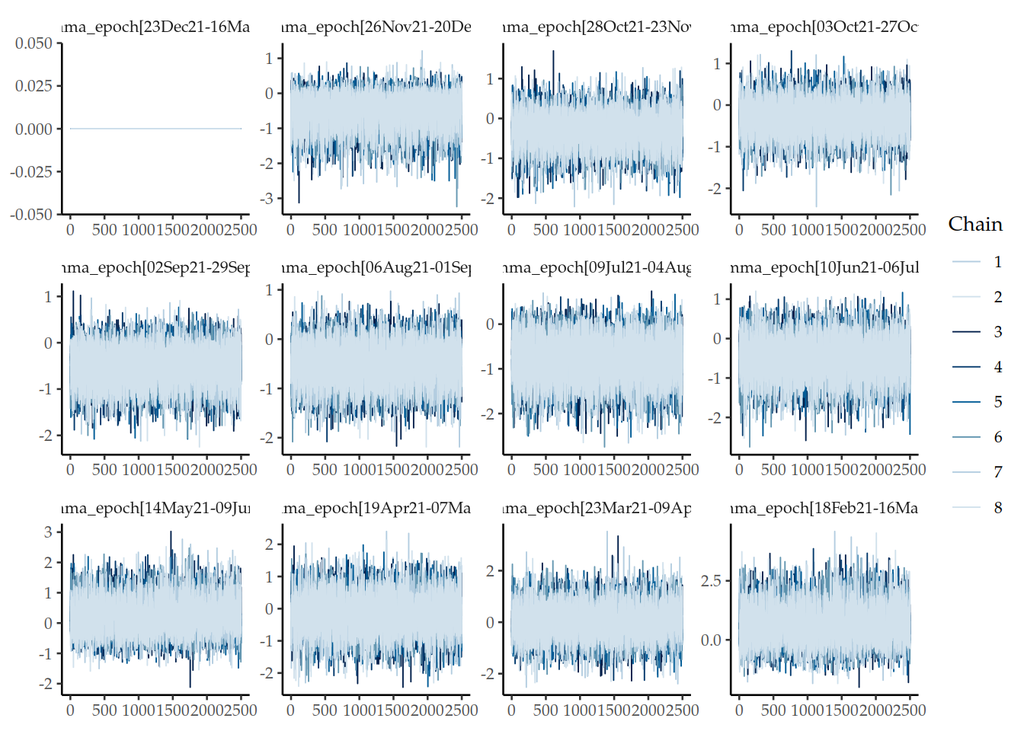

```r
mcmc_trace(res$drws["gamma_epoch"])
```

#### Posterior Predictive

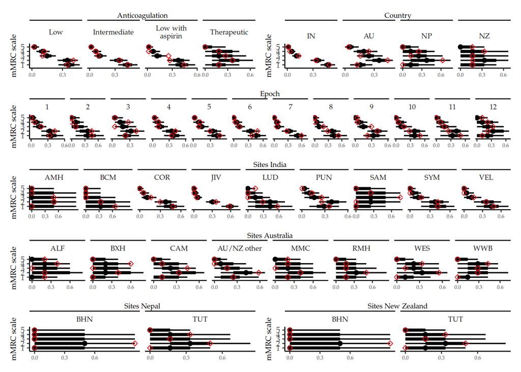

```r
y_ppc <- res$drws$y_ppc
ppc_dat <- bind_cols(acs_itt_nona_dat, tibble(y_ppc = y_ppc)) %>%
  mutate(CAssignment = factor(
    CAssignment,
    levels = names(intervention_labels_short_break()$CAssignment),
    labels = intervention_labels_short_break()$CAssignment))


plot_grp_ppc <- function(dat, lab = "", xlab = "Probability") {
  ggplot(dat %>%
           filter(response == "ypp", event == "eq"),
         aes(y = out)) +
    facet_wrap( ~ grp, nrow = 1, scales = "free_x") +
    stat_pointinterval(aes(xdist = posterior), fatten_point = 1)  +
    geom_point(data = dat %>% filter(response == "y", event == "eq"),
               aes(y = out, x = mean(posterior)),
               colour = "red",
               shape = 23) +
    scale_x_continuous(
      xlab, breaks = c(0, 0.3, 0.6),
      sec.axis = sec_axis(
        ~ . , name = lab, breaks = NULL, labels = NULL)) +
    scale_y_continuous("mMRC scale") +
    theme(strip.text = element_text(size = rel(0.7)),
          axis.title.x = element_text(size = rel(0.7)),
          axis.text.x = element_text(size = rel(0.65)),
          axis.title.y = element_text(size = rel(0.75)),
          axis.title.x.bottom = element_blank())
}

pp_C <- ordinal_grp_ppc(out_mmrc_scale, CAssignment, 1:5)
pp_ctry <- ordinal_grp_ppc(out_mmrc_scale, country, 1:5)
pp_epoch <- ordinal_grp_ppc(out_mmrc_scale, epoch, 1:5)
pp_site <- ordinal_grp_ppc(out_mmrc_scale, site, 1:5) %>%
  left_join(ppc_dat %>% dplyr::count(site, country),
            by = c("grp" = "site"))

p1 <- plot_grp_ppc(pp_C, "Anticoagulation", "")
p2 <- plot_grp_ppc(pp_ctry, "Country", "")
p3 <- plot_grp_ppc(pp_epoch, "Epoch", "")
p4 <- plot_grp_ppc(
  pp_site %>% filter(country == "IN"), "Sites India", "")
p5 <- plot_grp_ppc(
  pp_site %>% filter(country == "AU"), "Sites Australia", "")
p6 <- plot_grp_ppc(
  pp_site %>% filter(country == "NP"), "Sites Nepal", "")
p7 <- plot_grp_ppc(
  pp_site %>% filter(country == "NP"), "Sites New Zealand", "")

p <- (p1 | p2) / p3 / p4 / p5 / (p6 | p7)
pth <- file.path("outputs", "figures", "outcomes", "secondary",
                 "7-7-primary-model-acs-itt-ppc.pdf")
ggsave(pth, p, width = 6, height = 5.75)
p
```

### Sensitivity: Treatment Coding

```r
res <- fit_primary_model(acs_itt_nona_dat, contr.treatment)
```

```
Running MCMC with 8 chains, at most 4 in parallel...

Chain 1 finished in 35.9 seconds.
Chain 2 finished in 40.4 seconds.
Chain 3 finished in 41.8 seconds.
Chain 4 finished in 42.7 seconds.
Chain 8 finished in 31.1 seconds.
Chain 5 finished in 41.7 seconds.
Chain 7 finished in 48.8 seconds.
Chain 6 finished in 52.9 seconds.

All 8 chains finished successfully.
Mean chain execution time: 41.9 seconds.
Total execution time: 93.6 seconds.
```

```r
odds_ratio_summary_table(res$drws$OR)
```

| Parameter | Median | 95% CrI | Mean (SD) | Pr(OR < 1) |
| --- | --- | --- | --- | --- |
| Intermediate | 0.67 | (0.40, 1.09) | 0.69 (0.18) | 0.95 |
| Low with aspirin | 1.01 | (0.53, 1.94) | 1.07 (0.37) | 0.48 |
| Therapeutic | 0.60 | (0.21, 1.77) | 0.70 (0.42) | 0.82 |
| Ineligible aspirin | 0.99 | (0.24, 3.97) | 1.27 (1.03) | 0.51 |
| Age ≥ 60 | 1.51 | (0.94, 2.45) | 1.55 (0.38) | 0.05 |
| Australia/New Zealand | 2.86 | (0.78, 10.40) | 3.54 (2.60) | 0.06 |
| Nepal | 1.38 | (0.31, 5.39) | 1.76 (1.42) | 0.33 |

### Sensitivity: Reduced Models

**Full design model plus site**

```r
dat_full <- make_stan_data(
  dat = acs_itt_nona_dat,
  vars    = c("inelgc3", "agegte60", "ctry"),
  outcome = "out_mmrc_scale",
  beta_sd = c(10, 2.5, 1, 1))
stan_region <- run_stan(model_site, dat_full)
```

```
Running MCMC with 8 chains, at most 4 in parallel...

Chain 3 finished in 10.0 seconds.
Chain 1 finished in 10.4 seconds.
Chain 4 finished in 10.8 seconds.
Chain 2 finished in 10.9 seconds.
Chain 5 finished in 11.4 seconds.
Chain 7 finished in 11.3 seconds.
Chain 8 finished in 11.2 seconds.
Chain 6 finished in 11.8 seconds.

All 8 chains finished successfully.
Mean chain execution time: 11.0 seconds.
Total execution time: 22.5 seconds.
```

**Full design model plus site**

```r
stan_region$cmdstan_diagnose()
```

```
Processing csv files: /tmp/RtmppbiH2j/logistic_cumulative_site-202207131223-1-663da7.csv, /tmp/RtmppbiH2j/logistic_cumulative_site-202207131223-2-663da7.csv, /tmp/RtmppbiH2j/logistic_cumulative_site-202207131223-3-663da7.csv, /tmp/RtmppbiH2j/logistic_cumulative_site-202207131223-4-663da7.csv, /tmp/R…

Checking sampler transitions treedepth.
Treedepth satisfactory for all transitions.

Checking sampler transitions for divergences.
No divergent transitions found.

Checking E-BFMI - sampler transitions HMC potential energy.
E-BFMI satisfactory.

Effective sample size satisfactory.

Split R-hat values satisfactory all parameters.

Processing complete, no problems detected.
```

**Full design model plus site**

```r
stan_region$summary(variables = c("p0", "alpha", "beta"))
```

```
# A tibble: 18 × 10
   variable    mean  median     sd    mad       q5     q95  rhat ess_bulk
   <chr>      <dbl>   <dbl>  <dbl>  <dbl>    <dbl>   <dbl> <dbl>    <dbl>
 1 p0[1]     0.284   0.280  0.0941 0.100   0.137    0.445   1.00    5046.
 2 p0[2]     0.412   0.414  0.0403 0.0386  0.344    0.474   1.00   14470.
 3 p0[3]     0.181   0.176  0.0528 0.0550  0.104    0.277   1.00    5714.
 4 p0[4]     0.101   0.0916 0.0445 0.0385  0.0465   0.185   1.00    5919.
 5 p0[5]     0.0227  0.0191 0.0145 0.0107  0.00731  0.0499  1.00    8196.
 6 alpha[1] -0.979  -0.947  0.497  0.501  -1.84    -0.219   1.00    5046.
 7 alpha[2]  0.867   0.897  0.479  0.485   0.0380   1.60    1.00    5107.
 8 alpha[3]  2.05    2.07   0.485  0.488   1.21     2.80    1.00    5682.
 9 alpha[4]  3.93    3.94   0.600  0.598   2.95     4.91    1.00    8196.
10 beta[1]  -0.105  -0.105  0.431  0.435  -0.820    0.600   1.00   20515.
11 beta[2]   0.186   0.184  0.239  0.241  -0.204    0.581   1.00   20139.
12 beta[3]  -0.184  -0.183  0.279  0.279  -0.642    0.275   1.00   20183.
13 beta[4]  -0.0266 -0.0202 0.585  0.573  -1.00     0.932   1.00   17537.
14 beta[5]  -0.211  -0.212  0.351  0.348  -0.782    0.370   1.00   33946.
15 beta[6]   0.0938  0.102  0.687  0.679  -1.05     1.21    1.00   32214.
16 beta[7]   0.430   0.431  0.240  0.237   0.0343   0.824   1.00   30574.
17 beta[8]   0.793   0.799  0.646  0.645  -0.267    1.85    1.00    9995.
18 beta[9]   0.259   0.268  0.731  0.727  -0.952    1.43    1.00   15576.
# … with 1 more variable: ess_tail <dbl>
```

### Expanded Outcome

```r
res <- fit_primary_model(acs_itt_nona2_dat)
```

```
Running MCMC with 8 chains, at most 4 in parallel...

Chain 2 finished in 185.1 seconds.
Chain 4 finished in 185.2 seconds.
Chain 3 finished in 208.7 seconds.
Chain 1 finished in 239.8 seconds.
Chain 8 finished in 175.0 seconds.
Chain 5 finished in 230.8 seconds.
Chain 7 finished in 218.0 seconds.
Chain 6 finished in 288.5 seconds.

All 8 chains finished successfully.
Mean chain execution time: 216.4 seconds.
Total execution time: 474.3 seconds.
```

```r
odds_ratio_summary_table(res$drws$OR)
```

| Parameter | Median | 95% CrI | Mean (SD) | Pr(OR < 1) |
| --- | --- | --- | --- | --- |
| Intermediate | 0.74 | (0.53, 1.02) | 0.75 (0.13) | 0.97 |
| Low with aspirin | 1.15 | (0.76, 1.73) | 1.18 (0.25) | 0.25 |
| Therapeutic | 0.92 | (0.39, 2.11) | 1.00 (0.45) | 0.58 |
| Ineligible aspirin | 1.21 | (0.45, 2.99) | 1.34 (0.67) | 0.35 |
| Age ≥ 60 | 1.93 | (1.41, 2.64) | 1.95 (0.31) | 0.00 |
| Australia/New Zealand | 0.67 | (0.18, 2.55) | 0.85 (0.65) | 0.72 |
| Nepal | 0.29 | (0.05, 2.43) | 0.52 (0.75) | 0.87 |

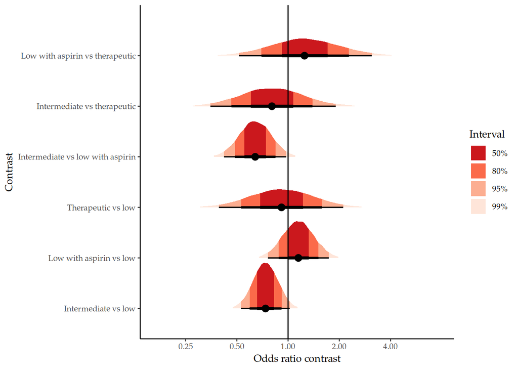

```r
plot_or_densities(res$drws$compare)
```

```r
res <- fit_primary_model(acs_itt_nona2_dat, contr.treatment)
```

```
Running MCMC with 8 chains, at most 4 in parallel...

Chain 2 finished in 211.3 seconds.
Chain 4 finished in 211.7 seconds.
Chain 3 finished in 229.8 seconds.
Chain 1 finished in 236.8 seconds.
Chain 5 finished in 175.8 seconds.
Chain 8 finished in 181.3 seconds.
Chain 7 finished in 199.7 seconds.
Chain 6 finished in 225.7 seconds.

All 8 chains finished successfully.
Mean chain execution time: 209.0 seconds.
Total execution time: 438.0 seconds.
```

```r
odds_ratio_summary_table(res$drws$OR)
```

| Parameter | Median | 95% CrI | Mean (SD) | Pr(OR < 1) |
| --- | --- | --- | --- | --- |
| Intermediate | 0.70 | (0.50, 0.96) | 0.71 (0.12) | 0.99 |
| Low with aspirin | 1.08 | (0.72, 1.61) | 1.11 (0.23) | 0.35 |
| Therapeutic | 0.76 | (0.32, 1.72) | 0.82 (0.36) | 0.75 |
| Ineligible aspirin | 1.19 | (0.44, 2.97) | 1.32 (0.66) | 0.36 |
| Age ≥ 60 | 1.94 | (1.42, 2.66) | 1.97 (0.31) | 0.00 |
| Australia/New Zealand | 0.73 | (0.19, 2.68) | 0.91 (0.68) | 0.68 |
| Nepal | 0.29 | (0.05, 2.35) | 0.52 (0.79) | 0.88 |

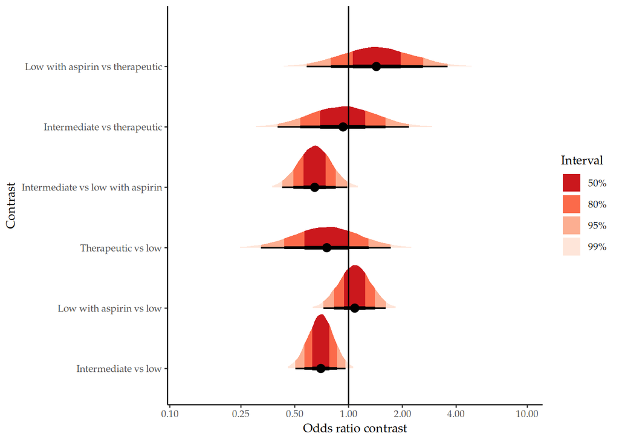

```r
plot_or_densities(res$drws$compare)
```